# Natural kinds statistical analysis

2022-11-16

## Overview

I have included below a report of descriptive statistics (with plots and tables) and the results of the Bayesian models. The tables should be easy to copy-paste and you can remove the control conditions if you like. I included 2 options for one of the model outputs (the same information is presented from a different angle). I can re-orient any plot, change colors, and take out irrelevant variables for any of these plots easily. I also have a brief explanation of each plot and table below.

## Statistical Analysis

Two Bayesian models were run - one ordinal regression and one multinomial regression. The outcome variable of the ordinal model was rating (1-7), while the outcome variable of the multinomial model was the probability of choosing “both”, “is” or “is not”. The fixed and random effect strucutres of both models was the same. The sole fixed effect predictor included was “kind” (6 levels). The model also included random intercepts for participant and what is labeled “spec” in the data.

brms syntax for the ordinal model: `rating ~ kind + (1 | prolific_id) + (1 | spec)`

brms syntax for the multinomial model: `response ~ kind + (1 | prolific_id) + (1 | spec)` The outcome `response` had three levels `both`, `is` or `is_not`.

The predictor `kind` had six levels in the multinomial model: `natural kind`, `abstract. concept`, `artifact`, `control precise definition`, `control subjective adjective` and `control check`. In the ordinal model, `kind` had five of six levels (`control check` was omitted).

The random intercept for `prolific_id` was for participants and there were 51 in the multinomial model and 47 in the ordinal model. The random intercept for `spec` was for the specific example used in the experiment and there were 25 unique types in the data for the multinomial model and 22 unique types in the ordinal model.

The models both included the default brms priors - Student’s T distribution with 3 degrees of freedom. The model was run using with 4000 iterations of Hamiltonian Monte-Carlo sampling (1000 warm up), across 4 chains and 8 processing cores.

## Results

### Multinomial Descriptive Statistics

This is simply a histogram of each response for three of the levels of `kind` that we had discussed in a meeting.

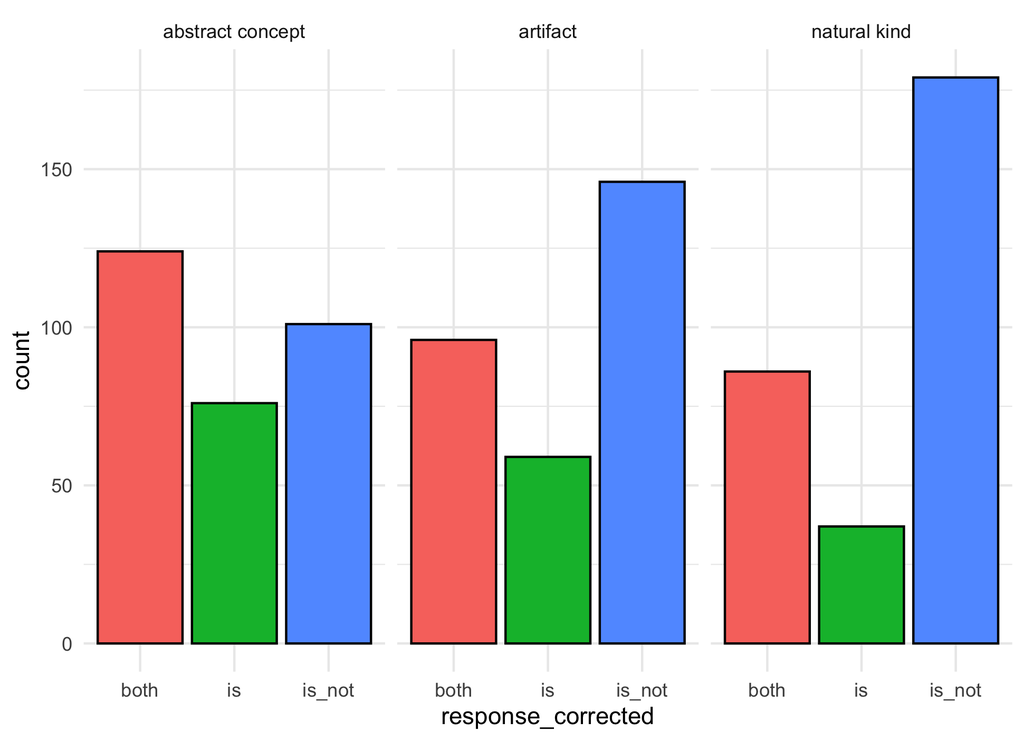

### Multinomial Model

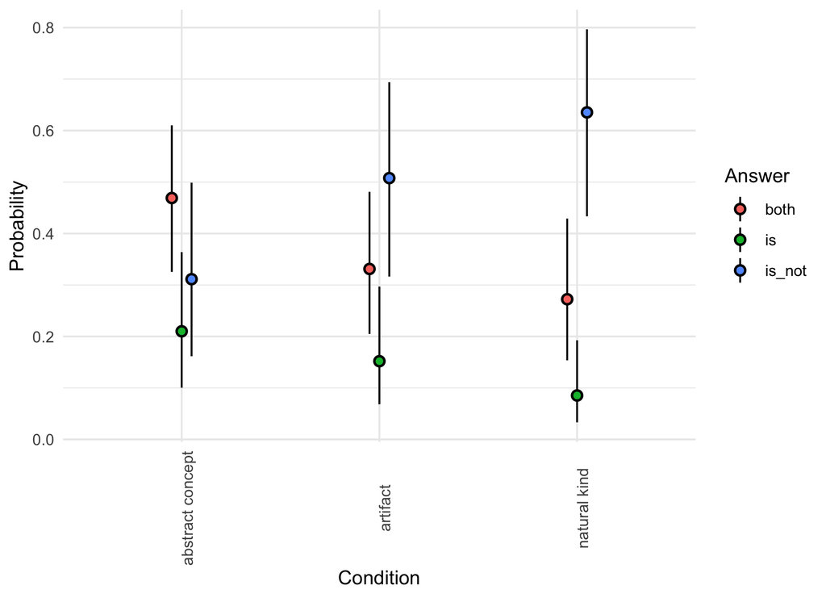

| Kind | both | is | is_not |
| --- | --- | --- | --- |
| abstract concept | 0.47 [0.33 - 0.61] | 0.21 [0.1 - 0.36] | 0.31 [0.16 - 0.5] |
| artifact | 0.33 [0.2 - 0.48] | 0.15 [0.07 - 0.3] | 0.51 [0.32 - 0.69] |
| control check | 0.21 [0.1 - 0.38] | 0.23 [0.07 - 0.5] | 0.54 [0.26 - 0.79] |
| control precise definition | 0.02 [0 - 0.09] | 0.03 [0 - 0.15] | 0.95 [0.79 - 0.99] |
| control subjective adjective | 0.81 [0.57 - 0.93] | 0.17 [0.06 - 0.41] | 0.01 [0 - 0.07] |
| natural kind | 0.27 [0.15 - 0.43] | 0.09 [0.03 - 0.19] | 0.64 [0.43 - 0.8] |

### Ordinal Descriptive Statistics

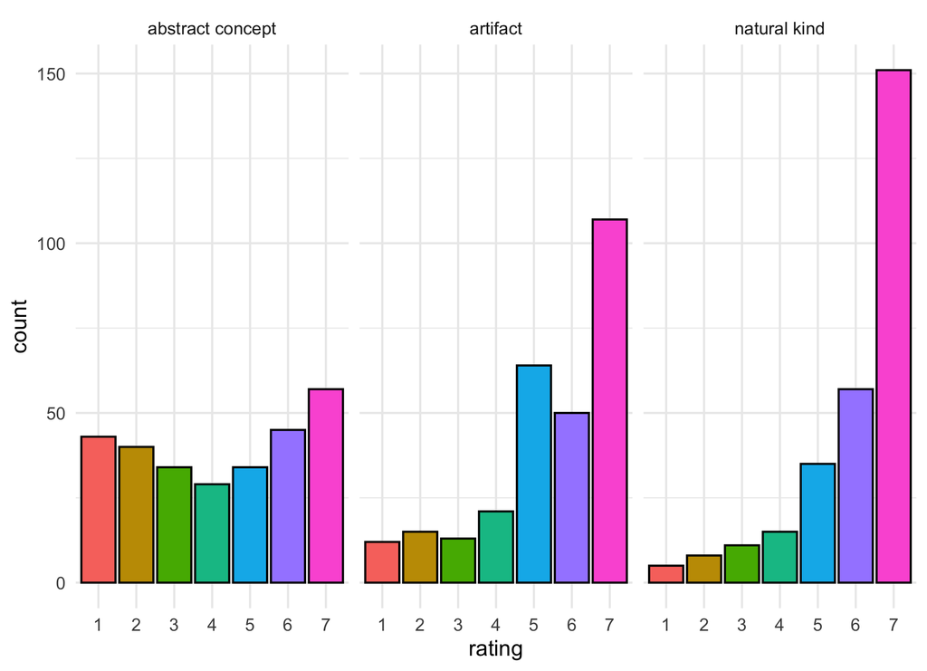

### Ordinal Model

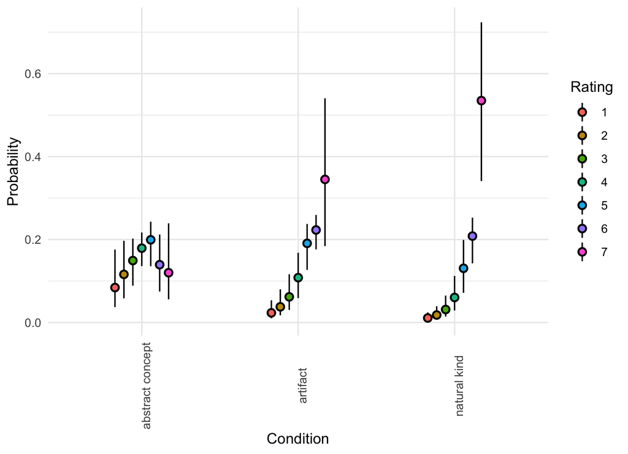

### Ordinal Model (option 2)

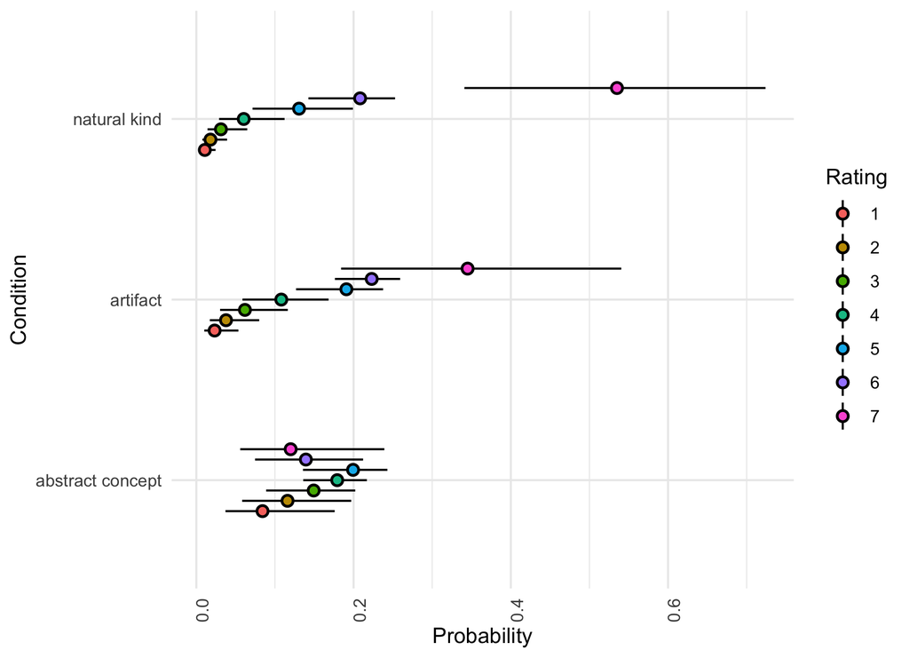

| Kind | 1 | 2 | 3 | 4 | 5 | 6 |
| --- | --- | --- | --- | --- | --- | --- |
| abstract concept | 0.08 [0.04 - 0.18] | 0.12 [0.06 - 0.2] | 0.15 [0.09 - 0.2] | 0.18 [0.14 - 0.22] | 0.2 [0.14 - 0.24] | 0.14 [0.07 - 0.21] |
| artifact | 0.02 [0.01 - 0.05] | 0.04 [0.02 - 0.08] | 0.06 [0.03 - 0.12] | 0.11 [0.06 - 0.17] | 0.19 [0.13 - 0.24] | 0.22 [0.18 - 0.26] |
| control precise definition | 0 [0 - 0.02] | 0.01 [0 - 0.03] | 0.01 [0 - 0.05] | 0.02 [0.01 - 0.09] | 0.06 [0.02 - 0.17] | 0.13 [0.04 - 0.23] |
| control subjective adjective | 0.18 [0.05 - 0.46] | 0.19 [0.08 - 0.27] | 0.18 [0.1 - 0.22] | 0.16 [0.08 - 0.21] | 0.14 [0.05 - 0.23] | 0.07 [0.02 - 0.18] |
| natural kind | 0.01 [0 - 0.02] | 0.02 [0.01 - 0.04] | 0.03 [0.01 - 0.06] | 0.06 [0.03 - 0.11] | 0.13 [0.07 - 0.2] | 0.21 [0.14 - 0.25] |

## Multinomial Model table

```
## 'bayes_R2' is not defined for unordered categorical models.
```

|  | response_corrected: is |  | response_corrected: isnot |  |
| --- | --- | --- | --- | --- |
| Predictors | Odds Ratios | CI (95%) | Odds Ratios | CI (95%) |
| Intercept | 0.45 | 0.20 – 0.93 | 0.66 | 0.29 – 1.46 |
| kindartifact | 1.03 | 0.39 – 2.81 | 2.31 | 0.79 – 6.65 |
| kindcontrolcheck | 2.46 | 0.72 – 8.15 | 3.83 | 1.02 – 14.74 |
| kindcontrolprecisedefinition | 3.39 | 0.48 – 27.64 | 74.57 | 12.28 – 621.66 |
| kindcontrolsubjectiveadjective | 0.48 | 0.12 – 1.90 | 0.02 | 0.00 – 0.16 |
| kindnaturalkind | 0.71 | 0.25 – 2.04 | 3.51 | 1.19 – 10.31 |
| Random Effects |  |  |  |  |
| σ<sup>2</sup> | -0.03 |  |  |  |
| τ<sub>00</sub> | 0.82 |  |  |  |
| ICC | -0.04 |  |  |  |
| N <sub>prolific_id</sub> | 51 |  |  |  |
| N <sub>spec</sub> | 25 |  |  |  |
| Observations | 1252 |  |  |  |

## Ordinal Model table

|  | as integer(rating) |  |
| --- | --- | --- |
| Predictors | Odds Ratios | CI (95%) |
| kindartifact | 3.82 | 1.21 – 11.76 |
| kindcontrolprecisedefinition | 22.47 | 4.60 – 124.13 |
| kindcontrolsubjectiveadjective | 0.43 | 0.09 – 2.03 |
| kindnaturalkind | 8.44 | 2.75 – 27.10 |
| Random Effects |  |  |
| σ<sup>2</sup> | 0.41 |  |
| τ<sub>00</sub> | 3.39 |  |
| ICC | 0.11 |  |
| N <sub>prolific_id</sub> | 47 |  |
| N <sub>spec</sub> | 22 |  |
| Observations | 1034 |  |
| Marginal R<sup>2</sup> / Conditional R<sup>2</sup> | 0.247 / 0.413 |  |

## Multinomial Model table

| Parameter | Median | Mean | MAP | CI | CI_low | CI_high | pd | ps | Rhat | ESS |
| --- | --- | --- | --- | --- | --- | --- | --- | --- | --- | --- |
| b_muis_Intercept | -0.801 | -0.815 | -0.741 | 0.95 | -1.633 | -0.069 | 0.985 | 0.970 | 1.002 | 2217.664 |
| b_muisnot_Intercept | -0.413 | -0.419 | -0.385 | 0.95 | -1.254 | 0.380 | 0.854 | 0.792 | 1.000 | 1911.517 |
| b_muis_kindartifact | 0.029 | 0.031 | 0.012 | 0.95 | -0.946 | 1.033 | 0.524 | 0.438 | 1.000 | 2619.731 |
| b_muis_kindcontrolcheck | 0.902 | 0.898 | 0.905 | 0.95 | -0.330 | 2.098 | 0.930 | 0.904 | 1.000 | 2851.101 |
| b_muis_kindcontrolprecisedefinition | 1.220 | 1.224 | 0.991 | 0.95 | -0.744 | 3.319 | 0.886 | 0.868 | 1.000 | 4563.873 |
| b_muis_kindcontrolsubjectiveadjective | -0.742 | -0.742 | -0.723 | 0.95 | -2.103 | 0.640 | 0.872 | 0.838 | 1.001 | 3199.803 |
| b_muis_kindnaturalkind | -0.347 | -0.352 | -0.281 | 0.95 | -1.368 | 0.712 | 0.763 | 0.698 | 1.000 | 2639.615 |
| b_muisnot_kindartifact | 0.836 | 0.838 | 0.828 | 0.95 | -0.230 | 1.895 | 0.944 | 0.922 | 1.000 | 2143.196 |
| b_muisnot_kindcontrolcheck | 1.344 | 1.345 | 1.530 | 0.95 | 0.015 | 2.691 | 0.976 | 0.966 | 1.000 | 2589.925 |
| b_muisnot_kindcontrolprecisedefinition | 4.312 | 4.350 | 4.294 | 0.95 | 2.508 | 6.432 | 1.000 | 1.000 | 1.000 | 3944.543 |
| b_muisnot_kindcontrolsubjectiveadjective | -3.769 | -3.806 | -3.811 | 0.95 | -6.048 | -1.816 | 1.000 | 1.000 | 1.000 | 3732.562 |
| b_muisnot_kindnaturalkind | 1.256 | 1.255 | 1.263 | 0.95 | 0.173 | 2.333 | 0.988 | 0.981 | 1.000 | 2195.049 |

## Ordinal Model table

| Parameter | Median | Mean | MAP | CI | CI_low | CI_high | pd | ps | Rhat | ESS |
| --- | --- | --- | --- | --- | --- | --- | --- | --- | --- | --- |
| b_Intercept[1] | -2.387 | -2.394 | -2.289 | 0.95 | -3.257 | -1.544 | 1.000 | 1.000 | 1.001 | 1566.511 |
| b_Intercept[2] | -1.383 | -1.386 | -1.404 | 0.95 | -2.232 | -0.563 | 0.999 | 0.998 | 1.001 | 1526.719 |
| b_Intercept[3] | -0.610 | -0.615 | -0.591 | 0.95 | -1.464 | 0.215 | 0.929 | 0.895 | 1.001 | 1502.714 |
| b_Intercept[4] | 0.150 | 0.148 | 0.116 | 0.95 | -0.699 | 0.987 | 0.645 | 0.550 | 1.001 | 1515.809 |
| b_Intercept[5] | 1.048 | 1.044 | 1.029 | 0.95 | 0.205 | 1.896 | 0.992 | 0.986 | 1.001 | 1510.600 |
| b_Intercept[6] | 1.992 | 1.988 | 1.949 | 0.95 | 1.157 | 2.828 | 1.000 | 1.000 | 1.001 | 1524.377 |
| b_kindartifact | 1.340 | 1.342 | 1.348 | 0.95 | 0.193 | 2.465 | 0.989 | 0.982 | 1.003 | 1407.958 |
| b_kindcontrolprecisedefinition | 3.112 | 3.136 | 3.047 | 0.95 | 1.525 | 4.821 | 1.000 | 1.000 | 1.002 | 2226.879 |
| b_kindcontrolsubjectiveadjective | -0.855 | -0.857 | -0.803 | 0.95 | -2.400 | 0.706 | 0.866 | 0.835 | 1.000 | 2117.686 |
| b_kindnaturalkind | 2.133 | 2.137 | 2.090 | 0.95 | 1.012 | 3.300 | 1.000 | 1.000 | 1.001 | 1503.186 |

## References

Bürkner, P. (2017). “brms: An R Package for Bayesian Multilevel Models Using Stan.” *Journal of Statistical Software*, 80(1), 1–28. doi:10.18637/jss.v080.i01.